# lab1

# Лабораторная работа 1

## Исходные данные

Экспоненциальное распределение определяется следующей функцией распределения:

```
F(x) = 1 - e^(-λ⋅x)
```

Функция `rexp` генерирует случайные переменные при помощи экспоненциального распределения `rexp(n=42, rate=5)` вернёт 42 экспоненциально-распределённых числа с параметром (λ) равным 5. Ели второй аргумент не указан, будет использовано значение 1 т.е. получим “стандартное экспоненциальное распределение”.

## Задание 1

1. Сгенерируйте 200 случайных значений из стандартного экспоненциального распределения и сохраните в вектор *exp.1*. Найдите среднее и стандартное отклонение из данных этого вектора.

```r
exp.1 <- rexp(200)
exp.1
```

```
##   [1] 1.093043152 1.689616994 0.884805477 0.211863660 1.862613862
##   [6] 0.662489289 0.236936472 1.633571703 0.843848321 1.602925293
##  [11] 0.757939738 0.230458652 0.258674321 0.716097899 1.816602912
##  [16] 0.588140481 0.725372315 0.972511986 0.191187848 1.084424958
##  [21] 0.376419627 1.785821954 0.321796915 0.743481342 2.556402160
##  [26] 0.296785574 0.950781936 2.007425642 0.787860531 1.990355564
##  [31] 0.771657146 0.487835611 0.439927363 0.299166758 2.458793143
##  [36] 1.539673522 0.621522342 0.036212125 0.434148562 0.670421151
##  [41] 0.152893409 0.379078278 0.992559302 0.128818655 2.297600220
##  [46] 0.877647520 0.470188422 2.481886336 2.353166155 0.565129335
##  [51] 0.088421597 0.439825484 0.244003590 0.930868112 2.580610337
##  [56] 0.206203283 0.214442268 0.802758157 1.624611219 2.335880017
##  [61] 1.888650616 4.446247894 0.308115865 0.589774406 0.128413713
##  [66] 0.388819943 0.811585247 0.119506660 1.060264878 0.865024545
##  [71] 6.831425173 2.322568749 0.701306793 0.034324786 1.780571442
```

[output cut: 25 more lines]

```r
exp.1.mean <- mean(exp.1)
exp.1.mean
```

```
## [1] 0.9862977
```

```r
exp.1.sd <- sd(exp.1)
exp.1.sd
```

```
## [1] 0.9902615
```

2. Повторите, использовав следующие значения параметра λ: 0.1, 0.5, 5, 10, и сохраните результаты в векторы: *exp.0.1*, *exp.0.5*, *exp.5*, *exp.10*.

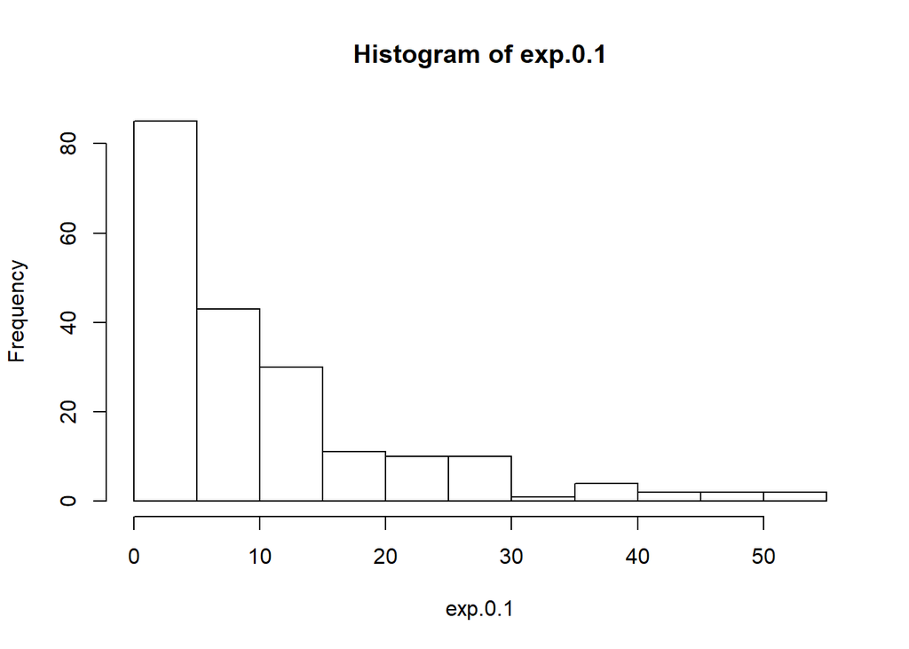

```r
exp.0.1<-rexp(200, 0.1)
exp.0.5<-rexp(200, 0.5)
exp.5<-rexp(200, 5)
exp.10<-rexp(200, 10)

hist(exp.0.1)
```

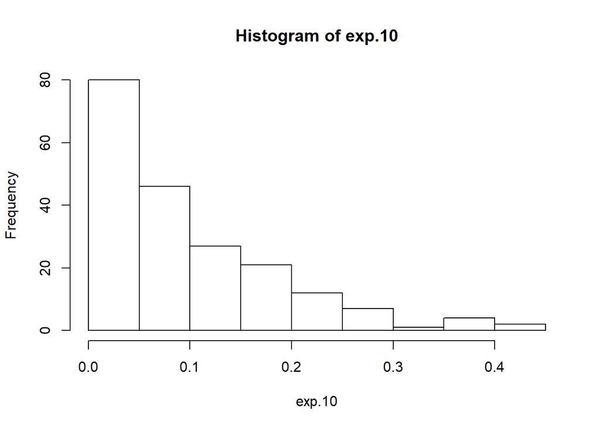

```r
hist(exp.10)
```

### mean

```r
exp.0.1.mean <- mean(exp.0.1)
exp.0.1.mean
```

```
## [1] 10.18243
```

```r
exp.0.5.mean <- mean(exp.0.5)
exp.0.5.mean
```

```
## [1] 1.867569
```

```r
exp.5.mean <- mean(exp.5)
exp.5.mean
```

```
## [1] 0.2042966
```

```r
exp.10.mean <- mean(exp.10)
exp.10.mean
```

```
## [1] 0.0960838
```

### sd

```r
exp.0.1.sd <- sd(exp.0.1)
exp.0.1.sd
```

```
## [1] 10.87487
```

```r
exp.0.5.sd <- sd(exp.0.5)
exp.0.5.sd
```

```
## [1] 1.961405
```

```r
exp.5.sd <- sd(exp.5)
exp.5.sd
```

```
## [1] 0.1949645
```

```r
exp.10.sd <- sd(exp.10)
exp.10.sd
```

```
## [1] 0.09098541
```

3. Функция `plot()` общая функция для визуализации данных. Функция `hist()` принимает данные и раскладывает их по корзинам. Чтобы использовать эти функции нужно для начала передать им данные, которые хотим визуализировать.
4. Используйте функцию `hist()` для построения гистограммы полученного ранее стандартного распределения.

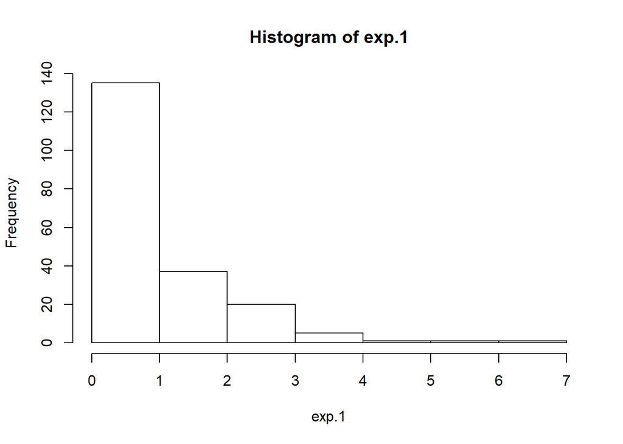

```r
hist(exp.1)
```

*Получена гистограмма стандартного распределения. Лучше увеличить количество наблюдений, сейчас их слишком мало.*

5. Используйте функцию `plot()` с тем же самым вектором для построения графика значений в порядке следования.

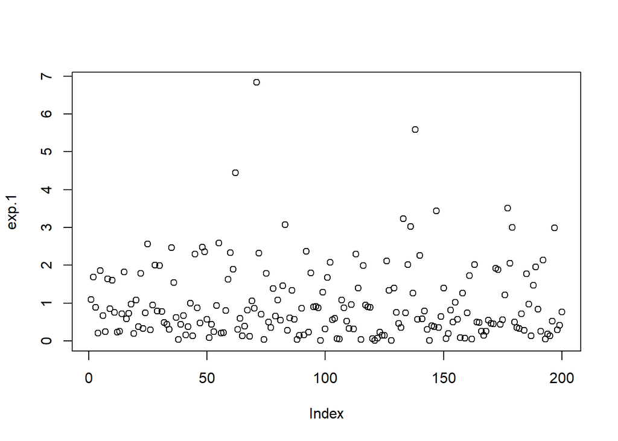

```r
plot(exp.1)
```

*Видно, что распределение неравномерно.*

6. Используйте функцию `plot()` с любыми двумя полученными ранее векторами, чтобы получить диаграмму рассеяния ([scatterplot](https://www.mathsisfun.com/data/scatter-xy-plots.html)) этих векторов относительно друг друга.

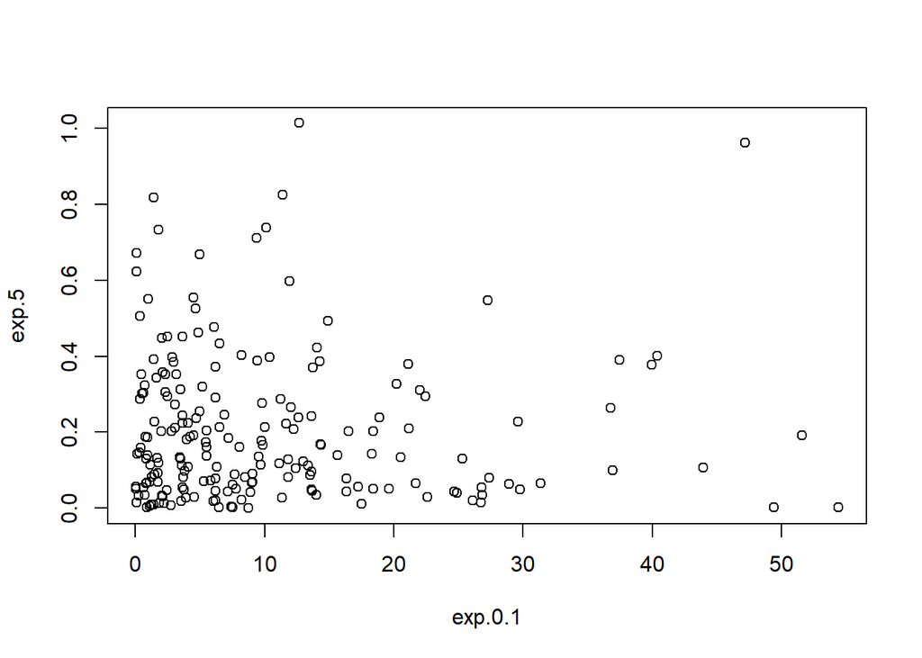

```r
  plot(exp.0.1,exp.5)
```

*На графике нет линейной зависимости.*

7. Теперь сравним свойства всех наших векторов. Для начала создадим вектор, содержащий средние значения каждого из 5 полученных ранее распределений в порядке их создания. Полученный вектор сохраним в переменную *exp.means*.

```r
exp.means <- c(exp.1.mean, exp.0.1.mean, exp.0.5.mean , exp.5.mean ,exp.10.mean)
exp.means
```

```
## [1]  0.9862977 10.1824252  1.8675688  0.2042966  0.0960838
```

```r
exp.sds <- c(exp.1.sd, exp.0.1.sd, exp.0.5.sd, exp.5.sd, exp.10.sd)
exp.sds
```

```
## [1]  0.99026154 10.87486525  1.96140459  0.19496452  0.09098541
```

Далее необходимо создать следующие диаграммы рассеяния: 8. Вектор с пятью средними относительно каждого из пяти векторов с различными значениями λ.

```r
# ? размерности не совпадают, повторим элементы
exp.means.repeat <- rep(exp.means,each = 40)
exp.means.repeat
```

```
##   [1]  0.9862977  0.9862977  0.9862977  0.9862977  0.9862977  0.9862977
##   [7]  0.9862977  0.9862977  0.9862977  0.9862977  0.9862977  0.9862977
##  [13]  0.9862977  0.9862977  0.9862977  0.9862977  0.9862977  0.9862977
##  [19]  0.9862977  0.9862977  0.9862977  0.9862977  0.9862977  0.9862977
##  [25]  0.9862977  0.9862977  0.9862977  0.9862977  0.9862977  0.9862977
##  [31]  0.9862977  0.9862977  0.9862977  0.9862977  0.9862977  0.9862977
##  [37]  0.9862977  0.9862977  0.9862977  0.9862977 10.1824252 10.1824252
##  [43] 10.1824252 10.1824252 10.1824252 10.1824252 10.1824252 10.1824252
##  [49] 10.1824252 10.1824252 10.1824252 10.1824252 10.1824252 10.1824252
##  [55] 10.1824252 10.1824252 10.1824252 10.1824252 10.1824252 10.1824252
##  [61] 10.1824252 10.1824252 10.1824252 10.1824252 10.1824252 10.1824252
##  [67] 10.1824252 10.1824252 10.1824252 10.1824252 10.1824252 10.1824252
##  [73] 10.1824252 10.1824252 10.1824252 10.1824252 10.1824252 10.1824252
##  [79] 10.1824252 10.1824252  1.8675688  1.8675688  1.8675688  1.8675688
##  [85]  1.8675688  1.8675688  1.8675688  1.8675688  1.8675688  1.8675688
```

[output cut: 19 more lines]

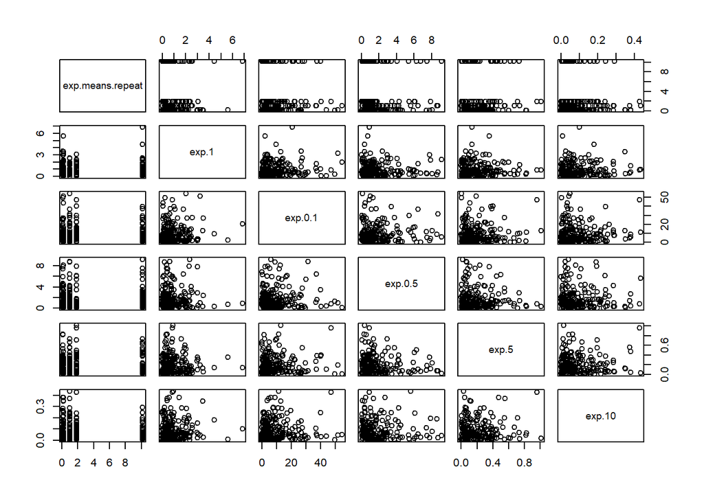

```r
# pairs: A matrix of scatterplots is produced.
pairs(~exp.means.repeat + exp.1 + exp.0.1 + exp.0.5 + exp.5 + exp.10) #formula
```

*Не видно линейной связи*

9. Вектор с пятью стандартными отклонениями относительно каждого из пяти векторов с различными значениями λ.

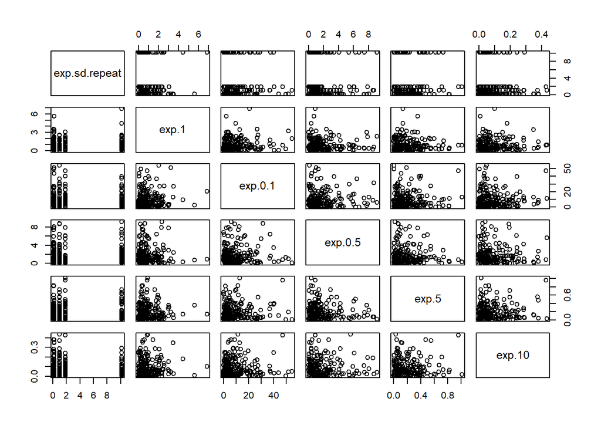

```r
exp.sd.repeat <- rep(exp.means,each=40);
pairs(~exp.sd.repeat + exp.1 + exp.0.1 + exp.0.5 + exp.5 + exp.10)
```

*Снова не видно линейной связи*

10. Вектор с пятью средними относительно вектора с пятью стандартными отклонениями.

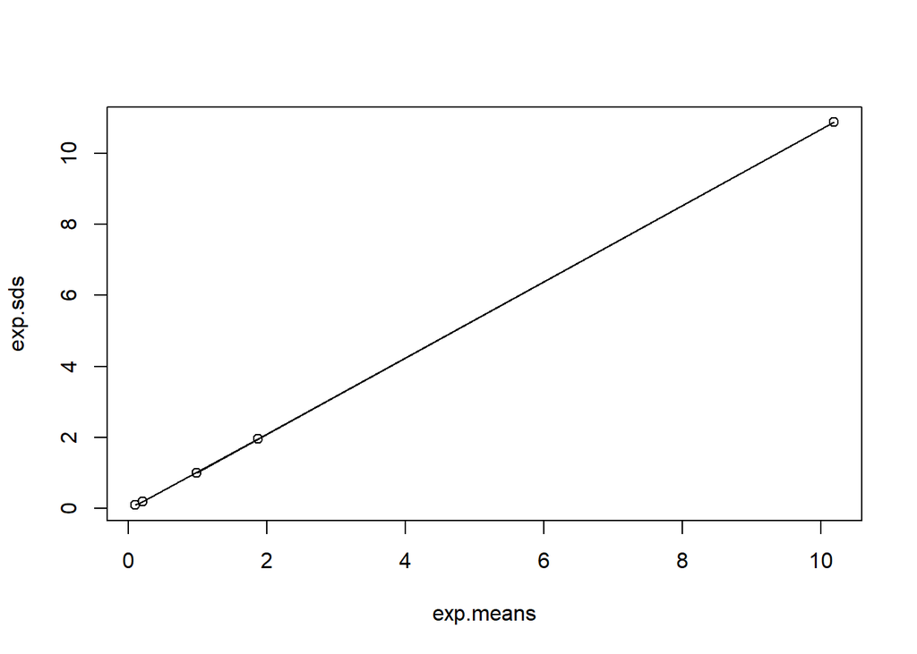

```r
plot(exp.means,exp.sds)
lines(exp.means,exp.sds)
```

*Видна линейная зависимость*

## Задание 2

R достаточно производителен, чтобы вычислять относительно большие объёмы данных. 1. Для демонстрации сгенерируйте 1100000 (1 млн. 100 тысяч) чисел из стандартного экспоненциального распределения и сохраните их в вектор *huge.exp.1*. Получите среднее и стандартное отклонение.

```r
huge.exp.1 <- rexp(1100000)
huge.exp.1.mean <- mean(huge.exp.1)
huge.exp.1.mean
```

```
## [1] 0.9992001
```

```r
huge.exp.1.sd <-sd (huge.exp.1)
huge.exp.1.sd
```

```
## [1] 0.9994721
```

2. Получите гистограмму *huge.exp.1*. Она соответствует функции `1 - e:^(-x)`? Должна ли?

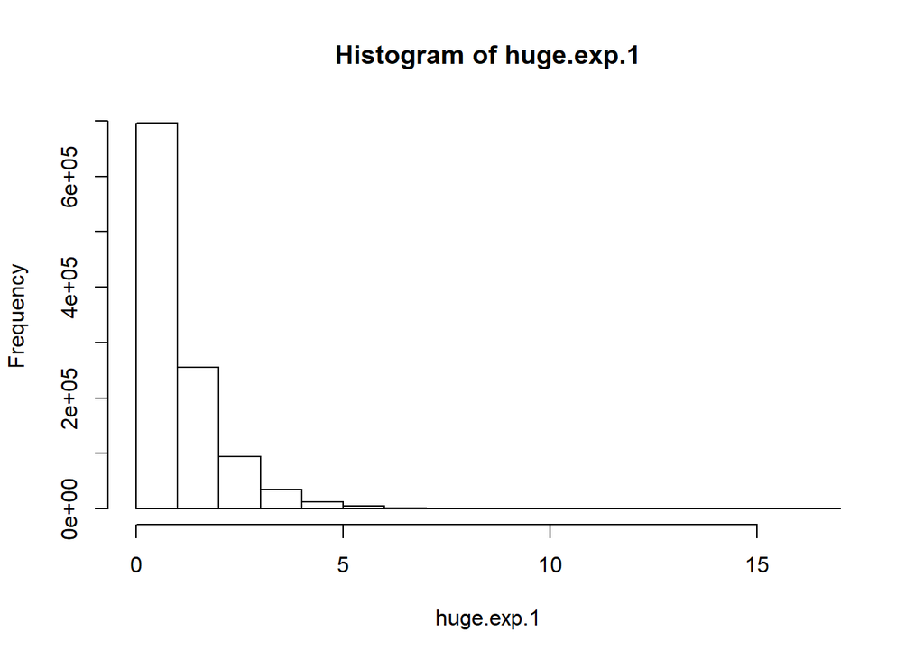

```r
hist(huge.exp.1)
```

3. Получите среднее всех чисел из *huge.exp.1* строго больших 1. Для проверки выборки может потребоваться новый вектор.

```r
mean.greater.1 <- mean(huge.exp.1 > 1)
mean.greater.1
```

```
## [1] 0.3677191
```

4. Получите матрицу *huge.exp.1.mat*, содержащую 1100 строк и 1000 колонок. Постройте гистограмму, использовав полученную матрицу. Что можно сказать о полученных данных?

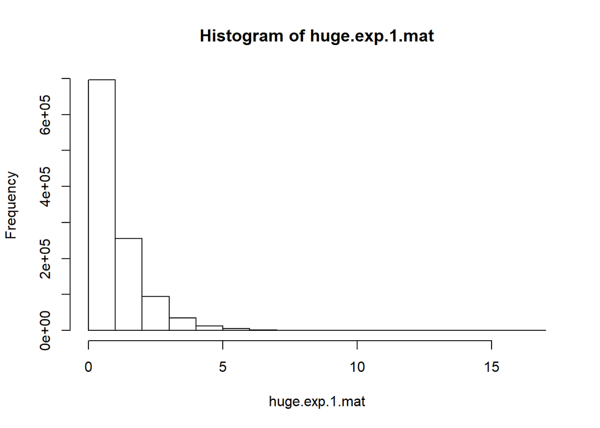

```r
huge.exp.1.mat <- matrix(huge.exp.1, nrow = 1100, ncol = 1000)
hist(huge.exp.1.mat)
```

*Гистограмма получилась такой же*

5. Рассчитайте среднее 137-й колонки из *huge.exp.1.mat*.

```r
mean.huge.mat.1.col137 <- colMeans(huge.exp.1.mat)[137]
mean.huge.mat.1.col137
```

```
## [1] 0.9800154
```

6. Найдите среднее всей 1000 колонок и сохраните их в вектор. Отобразите диаграмму средних зннчений колонок. Объясните почему форма диаграммы отличается от виденных ранее.

```r
mean.huge.mat.1.allCol <- colMeans(huge.exp.1.mat)
mean.huge.mat.1.allCol
```

```
##    [1] 1.0506314 0.9662972 1.0142187 1.0570840 0.9828459 0.9935274
##    [7] 0.9991601 0.9544631 1.0262087 0.9930322 0.9557260 1.0039254
##   [13] 1.0092983 0.9809341 0.9994599 0.9309575 1.0356663 1.0160548
##   [19] 0.9588072 0.9496915 1.0306684 0.9784776 0.9666463 1.0061170
##   [25] 0.9718319 1.0373077 1.0118667 0.9988393 0.9631973 0.9584809
##   [31] 0.9986189 1.0285850 1.0183153 0.9855397 0.9537568 0.9747608
##   [37] 0.9947267 0.9991767 0.9979233 1.0055575 0.9845538 0.9857181
##   [43] 0.9850340 0.9880246 1.0165738 0.9494333 0.9991090 0.9870504
##   [49] 0.9610340 0.9947416 1.0387725 1.0123180 1.0142086 1.0163039
##   [55] 0.9907253 0.9680168 1.0188181 0.9964620 0.9882581 1.0262207
##   [61] 1.0121795 1.0084386 0.9580506 1.0598077 1.0014997 0.9982683
##   [67] 1.0393343 0.9408167 0.9764138 0.9855956 1.0099214 1.0248983
##   [73] 1.0182327 1.0067127 1.0360761 0.9885501 1.0045862 1.0089876
##   [79] 0.9600563 0.9831776 1.0282301 1.0634422 1.0272239 0.9997818
##   [85] 1.0085183 0.9832290 1.0470333 0.9993925 0.9949837 1.0031925
```

[output cut: 152 more lines]

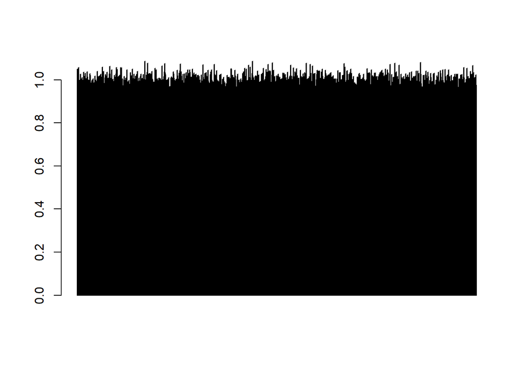

```r
barplot(mean.huge.mat.1.allCol)
```

7. Рассчитайте квадрат каждого значения из *huge.exp.1* и найдите среднее и стандартное отклонение полученного вектора квадратов. Объясните отличие от соответствующих показателей вектора *huge.exp.1*. Вам может помочь формула, по которой R рассчитывает стандартное отклонение: `sqrt(sum((x - mean(x))^2) / (n - 1))`.

```r
huge.exp.1.sqrt <- sqrt(huge.exp.1)
huge.exp.sqrt.mean <- mean(huge.exp.1.sqrt)
huge.exp.sqrt.mean
```

```
## [1] 0.8858289
```

```r
huge.exp.sqrt.sd <- sd(huge.exp.1.sqrt)
huge.exp.sqrt.sd
```

```
## [1] 0.4631495
```